# **Problem 1 Conservative one DOF system (25 pts)**

**Answers:**

## a. (12 pts) Formulate the non-dimensional equation of motion (EOM) of the system using Newton’s method.

**Answers:**

Define length of the string:

$$ l_x = \sqrt[]{l^2+x^2} \tag{1} $$

From equation:

$$ \sigma = E \epsilon \tag{2} $$

We can derive the tension force applied on the ball:

$$ T = \frac {EA(l_x-l)}{l} \tag{3} $$

After trigonometry analysis, the overall force exerted on the ball is:

$$ F = -2Tsin(\theta)= -2T\frac{x}{l_x} = -2\frac {EA(l_x-l)}{l}\frac{x}{l_x} \tag{4} $$

Where $\theta$ is the angle between the string and the vertical axis. Therefore, we can formulate equation of motion of the ball from Newton's Methond:

$$ m \ddot x= -\frac {2EA(\sqrt[]{l^2+x^2}-l)}{l \sqrt[]{l^2+x^2}}x \tag{5} $$

Nondimensionalize EOM by setting $u = x/l$, $\quad \omega =\sqrt[]{\frac{2EA}{ml}}, $$\quad\tau = t\omega$:

$$ \frac{d}{dt^2} = \frac{d}{d\tau^2}\omega^2 $$$$ u_{\tau\tau}= \frac{1-\sqrt[]{1+(u)^2}}{\sqrt[]{1+(u)^2}}u =ku \tag{6} $$

## b. (10 pts) Formulate the system approximate EOM under the assumption of small displacements

**Answers:**

Expand the stiffness term using Taylor series around $u = 0$, by Matlab symbolic function:

$$ k = \frac{1-\sqrt[]{1+(u)^2}}{\sqrt[]{1+(u)^2}} \approx -\frac{1}{2} u^2 +\frac{3}{8} u^4 + H.O.T. \tag{7} $$

Leaving first-order term approximation is:

$$ u_{\tau\tau}= ku = -\frac{1}{2}u^3 \tag{8} $$

## c. (3 pts) Is the system linear under the assumption of small displacements (in firstorder approximation)?

**Answers:**

If your first order approximation means first two term of Taylor series, then we have all zeros here -- linear. If your first order approximation means first term of non-zero Taylor series, then we have $-\frac{1}{2}u^3$ here -- nonlinear.

# **Problem 2 – Forced dynamical system (25 pts + 5 pts Bonus)**

## Q2.a. (5 pts) Find the dimensional EOM of the system with the help of Lagrange’s method.

**Answers:**

The moment of inertia $I$ of the rotating mass is: $$ I = m\ell^2 $$ The kinetic $T$ of the system is: $$ T = \frac{1}{2} I\omega ^2 = \frac{1}{2} m\ell^2 \omega^2 $$ If we consider gravity effect, the potential energy of the system is: $$ V = mg\ell\cos \theta + \frac{1}{2}k \theta^2 $$ And largrangian will be: $$ L = T-V = \frac{1}{2}m\ell^2 \dot \theta^2-mg\ell\cos \theta - \frac{1}{2}k \theta^2 $$ The generalized coordinates of the system are $\theta$, the non-conservative term will be: $$ Q_{NC} = 0 $$ And there's no torsional damping so the dissipation is negligible. $$ D = 0 $$ According to the Lagrange's equations, the equations of motion are: $$ \frac{\mathrm{d}}{\mathrm{d}t}{\partial{L}\over \partial{\dot \theta}} - {\partial{L}\over \partial \theta} + {\partial{D}\over \partial \dot \theta} = Q_{NC,\theta}, $$ Substituting $L$ in these equations and simplifying leads to the equations that describe the motion of the inverted pendulum: $$ m\ell^2 \ddot \theta - mg\ell \sin \theta + k\theta = 0 \\ \Rightarrow \ddot \theta - \frac{g}{\ell} \sin \theta + \frac{k}{I}\theta = 0 $$

## Question 2.b. (3 pts) Find two frequencies that play a role in the system's dynamic behavior. What are their physical meanings?

**Answers:**

The two frequencies are respectively: $$ \omega_g = \sqrt{\frac{g}{\ell}},\quad \omega_k = \sqrt{\frac{k}{I}} $$ $\omega_g$ is the natural frequency of the swinging pendulum, whereas $\omega_k$ is the natural frequency of the torsional spring. Thus the EOM can be written as: $$ \ddot \theta - \omega_g^2 \sin \theta + \omega_k^2 \theta = 0 $$

## Question 2.c. (3 pts) What is the natural frequency of the system?

**Answers:**

- $\omega_g$ is the natural frequency of the pendulum
- $\omega_k$ is the natural frequency of the torsional spring
- If $\theta \to 0 \Rightarrow \sin \theta \approx \theta$, then the natural frequency of the system is simplified as $\omega_{system}=\omega_g^2-\omega_k^2 = (\omega_g+\omega_k)(\omega_g-\omega_k)$

## Question 2.d

Apply a time normalization with respect to $\omega_{pend}= \sqrt[]{ g/l}$. Which nondimensional parameter dictates the system’s dynamics? What is its physical meaning?

**Answers:**

$$\omega_{pend}= \omega_g$$$$\tau = \omega_{g} t$$$$\ddot \theta = \frac{\rm d^2\theta}{\rm d t^2} = \frac{\rm d^2\theta}{\rm d \tau^2}\frac{\rm d \tau^2}{\rm dt^2} = \omega^2_{g} \theta_{\tau\tau}$$

Replacing EOM with non-dimensional $\ddot \theta$:

$$ \omega^2_{g} \theta_{\tau\tau} - \omega_g^2 \sin \theta + \omega_k^2 \theta = 0 \\ \Rightarrow \theta_{\tau\tau} - \sin \theta + (\frac{\omega_k}{\omega_g})^2 \theta = 0 $$

We can define the characteristic parameter $\eta_c$ as follows: $$ \eta_c = (\frac{\omega_k}{\omega_g})^2 = \frac{k}{gml} $$

It's clear that $\eta_c$ dictates the system’s dynamics. It means the dominance ratio between the torsional stiffness and the natural frequency of the pendulum. When $\eta_c$ is high, the structure is stiffer. When $\eta_c$ is low, the structure is softer.

## Question 2.e. (3 pts) Show the nondimensional EOM of the system.

**Answers:**

We already got this in the previous section. $$ \theta_{\tau\tau} - \sin \theta + \eta_c \theta = 0 $$

## Question 2.f. (3 pts)

Find the mathematical term which defines the equilibrium point of the system. Which nondimensional parameter dictates the value of the equilibrium points?

**Answers:**

The system is in equilibrium when $\theta_{\tau\tau} = \theta_{\tau} = 0$. Thus the EOM is reduced to:

$$ \sin \theta = \eta_c \theta $$

The root of this equation is the equilibrium point. The nondimensional parameter $\eta_c$ dictates the value of it. We can also express this in a reduced order representation.

$$ \Theta = \begin{pmatrix} \theta \\ \theta_\tau \end{pmatrix} = \begin{pmatrix} x_1 \\ x_2 \end{pmatrix} $$$$ \Theta_\tau = \begin{pmatrix} \theta_\tau \\ \theta_{\tau\tau} \end{pmatrix} = \begin{pmatrix} x_2 \\ \sin x_1-\eta_c x_1 \end{pmatrix} $$

As shown in the figure, if we set initial point at $\theta = 0.3$, there are three main catagoraries of system behaviors:

- when $\eta > 0.985$ the systems behaves like a normal pendulum, bauncing back and forth, the frequency increases when the parameter is larger. This is because the spring force takes bigger effect and makes it going up instead of falling down. ;
- when $\eta \approx0.985$, the pendulum stagnates at the initial point, that's because the gravity effect conteracts with string force, making the pendulum stays at initial point;
- when $\eta < 0.985$, the pendulum still oscillates, but instead of backing to the equilibrium($\theta =0 $), it falls down and back to the initial point of release. This is because the gravity takes bigger effect and makes it falls back instead of going up.

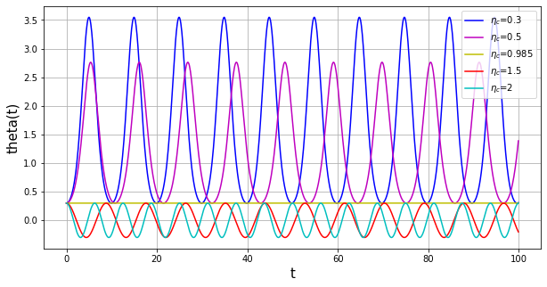

```python
# Importing relevant packages
import numpy as np
import matplotlib.pyplot as plt
import math
%matplotlib notebook
%matplotlib inline
from scipy.integrate import odeint

# Defining time vector, vector of initial conditions, and system parameter
tf, dt = 100, 0.1
t_vec = np.arange(0, tf, dt)

nd_paras = [0.3, 0.5, 0.985, 1.5, 2]

# DEfining the numerical solver for linear oscillator
def LO_EOM(x_vec, t):
    x1, x2 = x_vec
    x_vec_dot = [x2, math.sin(x1)-nd_para*x1]
    return x_vec_dot

x0 = 0.3
v0 = 0

color_vec = ['b', 'm', 'y','r', 'c']
plt.figure(figsize=(10,5))
for i, nd_para in enumerate(nd_paras):
    IC_vec = [x0, v0]
    sol = odeint(LO_EOM, IC_vec, t_vec)
    x, x_dot = sol[:, 0], sol[:, 1]
    plt.plot(t_vec,x, color_vec[i])

legend_lst = []
for i, nd_para in enumerate(nd_paras):
    legend_lst.append('$\eta_c$='+str(nd_para))


plt.grid()
plt.xlabel('t', fontsize=15); plt.ylabel('theta(t)', fontsize=15)
plt.legend(legend_lst, loc='upper right')
```

## Question 2.g. (5 pts + 5 pts Bonus)

Plot a bifurcation diagram that illustrates the evolution of the equilibrium point with respect to the bifurcation parameter. Hence, classify the equilibrium point types with a proper qualitative explanation. Refer only to the domain $\theta \in [-\pi,\pi]$ . For which value of the bifurcation parameter a bifurcation occurred? Which kind of bifurcation occurs? Give a qualitative/intuitive physical explanation for the bifurcation- what really happens in the system when the bifurcation parameter changes?

**Answers:** The bifurcation point is when $\eta_c = 1$. It's a super critical pitchfork bifurcation point.

- When $\eta_c < 1$, there are two stable equilibrium points (one possitive, one negative). And there is a unstable equilibrium point at $\theta =0$.
- When $\eta_c >1$, there is only one stable equilibrium point at $\theta =0 $.

It can be explained physically. When $\eta_c < 1$, it means the gravitational force is more dominant than the spring stiffness. The stable equilibrium happens on both side because the spring is too soft to support the pendulum in the middle. When $\eta_c > 1$, it means the gravitational force is less dominant than the spring stiffness. The spring is stiff enough to support the pendulum in the middle.

The bifurcation diagram is plotted via python(`scipy.optimize.fsolve`) as follows:

```
>>Loading solution file.
```

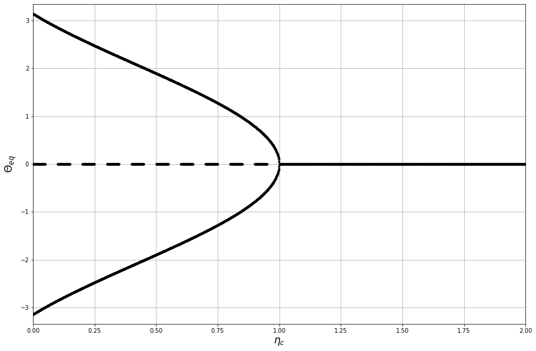

```python
import os.path
import math
import pandas as pd
import csv
from scipy.optimize import fsolve

# eta range
etas = np.linspace(0, 2, 2000)

# dotted line properties
dotted_line_length = 0.1
dotted_line_index = len(etas)*dotted_line_length/(etas[-1]-etas[0])/2

# create solution file if there's none
if not os.path.isfile('solution2.csv'):
  print('>>No solution file found, calculating solutions.')
  df = None
  for i, eta in enumerate(etas):
      theta = np.linspace(-math.pi,math.pi,201)
      func = lambda theta:eta*theta-math.sin(theta)
      # call function for calculating roots in domain
      if eta < 1:
        # calculate positive and negative roots
        theta_initail_guess1 = math.sqrt(6-6*eta)
        theta_solution1 = fsolve(func, theta_initail_guess1)
        theta_initail_guess3 = -math.sqrt(6-6*eta)
        theta_solution3 = fsolve(func, theta_initail_guess3)
        sol1 = {'eta':eta, 'theta':theta_solution1[0]}
        sol3 = {'eta':eta, 'theta':theta_solution3[0]}

        if df is None:
          df = pd.DataFrame(sol1, index=[0])
          df = df.append(sol3, ignore_index=True)
        else:
          df = df.append(sol1, ignore_index=True)
          df = df.append(sol3, ignore_index=True)

        # only calculate for dotted line region
        if i%(2*dotted_line_index)<dotted_line_index:
          # calculate zero roots
          theta_initail_guess2 = 0
          theta_solution2 = fsolve(func, theta_initail_guess2)
          sol2 = {'eta':eta, 'theta':theta_solution2[0]}
          df = df.append(sol2, ignore_index=True)

      else:
        # eta > 1, there's one stable EQP at 0
        theta_initail_guess2 = 0
        theta_solution2 = fsolve(func, theta_initail_guess2)
        sol2 = {'eta':eta, 'theta':theta_solution2[0]}
        df = df.append(sol2, ignore_index=True)

  print('>>Done Calculating! Saving the solutions to csv.')
  data_save = df.to_csv('solution2.csv')
  print('>>Solution Saved')

# load solution file
if os.path.isfile('solution2.csv'):
  print('>>Loading solution file.')
  # open output file for reading
  sols = pd.read_csv('solution2.csv')
  eta = sols['eta'].tolist()
  theta = sols['theta'].tolist()
  plt.figure(figsize=(15,10))
  plt.plot(eta, theta, 'o', color='gray',
        markersize=2, linewidth=1,
        markerfacecolor='black',
        markeredgecolor='black',
        markeredgewidth=2)
  plt.xlabel('$\eta_c$',size='xx-large')
  plt.ylabel('$\Theta_{eq}$',size='xx-large')
  plt.xlim([eta[0],eta[-1]])
  plt.grid(True)
  plt.ylim([-math.pi-0.2,math.pi+0.2])
```

# Problem 3 Equilibrium and bifurcation analysis

## Question 3.a (8 pts) For $r = 0$, find and classify all the equilibrium points and plot the obtained one-dimensional vector field.

**Answers:**

The equalilibrium points are where: $$ \dot x= 0 $$ For $r=0$ the equation is written as follows: $$ \sin x = 0 $$ The solution of this equation is $x = \pi k, k \in \mathbb{N}$

### Classification:

**Stable Equilibrium points:**

*Marked in Green in graph.

$$ x =2k\pi , \quad k \in \mathbb{Z}$$

**Unstable Equilibrium points:**

*Marked in Red in graph.

$$ x =(2k+1)\pi , \quad k \in \mathbb{Z}$$

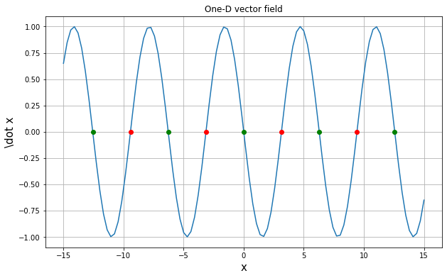

```python
plt.figure(figsize=[10,6])
x = np.linspace(-15,15,100)
y = - np.sin(x)
plt.plot(x,y, '-')
plt.plot([-4*3.141, -2*3.141,0, 2*3.141, 4*3.141],[0,0,0,0,0], 'o', markerfacecolor='green', markeredgecolor='green')
plt.plot([ -3*3.141, -3.141, 3.141, 3*3.141],[0,0,0,0], 'o', markerfacecolor='red',markeredgecolor='red')
plt.grid(True)
plt.xlabel('x', fontsize=15); plt.ylabel('\dot x', fontsize=15)
plt.title('One-D vector field')
# plt.legend(legend_lst, loc='upper right')
```

## Question 3.b (8 pts) Explain why for $r>1$ there is only one equilibrium point? And classify its type.

**Answers:**

The equalilibrium points are where: $$ \dot x= 0 $$

The function for calculating equilibrium is :

$$f(x) = rx -\sin x = 0$$

And its derivative is : $$f'(x) = r-\cos x$$

Remind that high school math class told us $\cos (x) \in [-1, 1]$ and $\cos (0) = 1$, we can conclude that when $r > 1$:

$$f'(x) >0$$

## Question 3.c (9 pts)

Plot a bifurcation diagram that presents the values of equilibrium points as a function of the $r$ parameter in the domain $0\leq r < \infty$. Add a qualitative explanation that portrays bifurcation occurrence during the diminution of r from $\infty$ to $0$.

**Answers:** The equalilibrium points are where:

$$ \dot x= 0 $$

So we need to solve for function:

$$ f(x) = rx-\sin x = 0 $$

From WalframAlpha, we noticed that when $r\geq 1$, the values of equilibrium points stagnates at a single solution $x = 0$. As we decrease the value of $r$, the number of solutions increase significantly with speed faster than a linear scale.

To calculate the solution numerically, we used Python. Since all numerical solvers actually outputs only one solution, we use a solver that repeatedly search solutions in a certain interval in order to find all solutions.

```python
# Define a solver to find all roots in a certain interval
import math

def rootsearch(f,a,b,dx):
    x1 = a; f1 = f(a)
    x2 = a + dx; f2 = f(x2)
    while f1*f2 > 0.0:
        if x1 >= b:
            return None,None
        x1 = x2; f1 = f2
        x2 = x1 + dx; f2 = f(x2)
    return x1,x2

def bisect(f,x1,x2,switch=0,epsilon=1.0e-9):
    f1 = f(x1)
    if f1 == 0.0:
        return x1
    f2 = f(x2)
    if f2 == 0.0:
        return x2
    if f1*f2 > 0.0:
        print('Root is not bracketed')
        return None
    n = int(math.ceil(math.log(abs(x2 - x1)/epsilon)/math.log(2.0)))
    for i in range(n):
        x3 = 0.5*(x1 + x2); f3 = f(x3)
        if (switch == 1) and (abs(f3) >abs(f1)) and (abs(f3) > abs(f2)):
            return None
        if f3 == 0.0:
            return x3
        if f2*f3 < 0.0:
            x1 = x3
            f1 = f3
        else:
            x2 =x3
            f2 = f3
    return (x1 + x2)/2.0

def roots(f, a, b, eps=1e-6):
    while 1:
        x1,x2 = rootsearch(f,a,b,eps)
        if x1 != None:
            a = x2
            root = bisect(f,x1,x2,1)
            if root != None:
                pass
                sol.append(round(root,-int(math.log(eps, 10))))
        else:
            break
```

```
>>Skip calculating! Loading solution file.
```

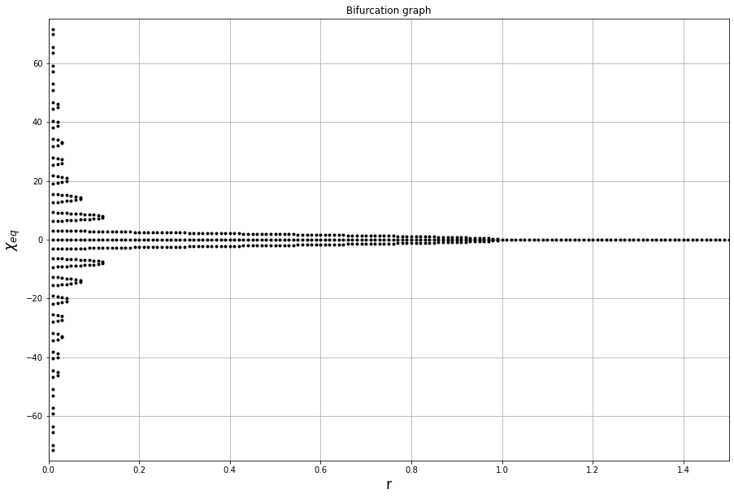

```python
import json
import os.path
rs = np.linspace(0.01, 2, 200)
plt.figure(figsize=(15,10))
sols = []
# define initial domain of search!
x_lower = 0
x_upper = 100
root_domain = [x_lower, x_upper]

if not os.path.isfile('solution.js'):  # if solution file not exists
  print('>>No solution file found, calculating solutions.')
  print('>>Takes a long time...')
  for i, r in enumerate(rs):
      print ('Handling r = %f, %d more to go.' % (r,rs.size - i -1))
      f=lambda x:r*x-math.sin(x)
      sol = []
      # call function for calculating roots in domain
      roots(f, root_domain[0], root_domain[-1])

      # domain for next search
      root_domain = [0, math.ceil(sol[-1])]

      # mirror the answer
      sol_array = np.array(sol)
      sol_array = np.concatenate([-np.flip(sol[1:]), sol_array])
      sol = sol_array.tolist()
      sols.append(sol)

      # Ploting
      plt.plot(r * np.ones_like(sol_array), sol_array, 'o', color='gray',
            markersize=3, linewidth=1,
            markerfacecolor='white',
            markeredgecolor='gray',
            markeredgewidth=2)
      plt.xlim([0, 1.5])
      print('Finnaly done!')
      # open output file for writing
      with open('solution.js', 'w') as filehandle:
          json.dump(sols, filehandle)
else:
  print('>>Skip calculating! Loading solution file.')
  # open output file for reading
  with open('solution.js', 'r') as filehandle:
      sols = json.load(filehandle)

  for i, r in enumerate(rs):
    plt.plot(r * np.ones_like(sols[i]), sols[i], 'o', color='gray',
          markersize=2, linewidth=1,
          markerfacecolor='black',
          markeredgecolor='black',
          markeredgewidth=2)
    plt.xlabel('r',size='xx-large')
    plt.ylabel('$\chi_{eq}$',size='xx-large')
    plt.title('Bifurcation graph')
    plt.xlim([0, 1.5])
    plt.grid(True)
    plt.ylim([-75, 75])
```

The bifurcation diagram dipects as above, all zeros when $x\geq 1$ and bifurcates when $r:1\rightarrow 0$.

The graph of $rx-\sin x$ contains two parts, $rx$ and $\sin x$: $rx$ is monotone increasing and has only one zero at $x = 0$, while $\sin x$ is periodical and has numerous solutions in our interval $x\in [0,\infty]$.

When $r>1$, the linear part is more significant. Though the graph is still oscillating, it does not has chance to intersect with the zero line.

When $r = 1$, the function is tangent with zero line at $x = 0$, that's where biferaction starts to take place.

We can further inspect on second bifercation, you can see our figure below, when $r\approx 0.13$, that when the local minima of the second period of $\sin x$ is interacting with zero line.

As $r$ continuously decreases, the whole graph becomes more "flat" because the $rx$ term is less dominant and period term becomes more significant, thus it bifercates and more solutions show up.

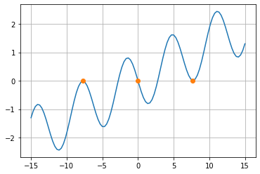

```python
# a plot showing 'bifurcation' phenomenon
x = np.linspace(-15,15,100)
y = 0.13*x - np.sin(x)
plt.plot(x,y, '-')
plt.plot([7.7,0,-7.7],[0,0,0], 'o')
plt.grid(True)
```

# Problem 4 - (25 pts + 5 pts Bonus ) Equilibrium and bifurcation analysis

A one-dimensional dynamical equation is given: $$ \dot x = r-x-e^{-x}$$

## Question 4.a. (15 pts)

For $0\leq r\leq3$ plot by MATLAB bifurcation diagram which portrays the evolution of the equilibrium point $x_eq$ versus the bifurcation parameter r. Describe the types of bifurcations and the r values of which the bifurcations took place. (5 pts Bonus for using python).

Just like what we did in question 3, let's solve equilibrium points $\chi_{eq}$ and obtain bifurcation graph using `Python`!

```
Skip calculating! Loading solution file.
```

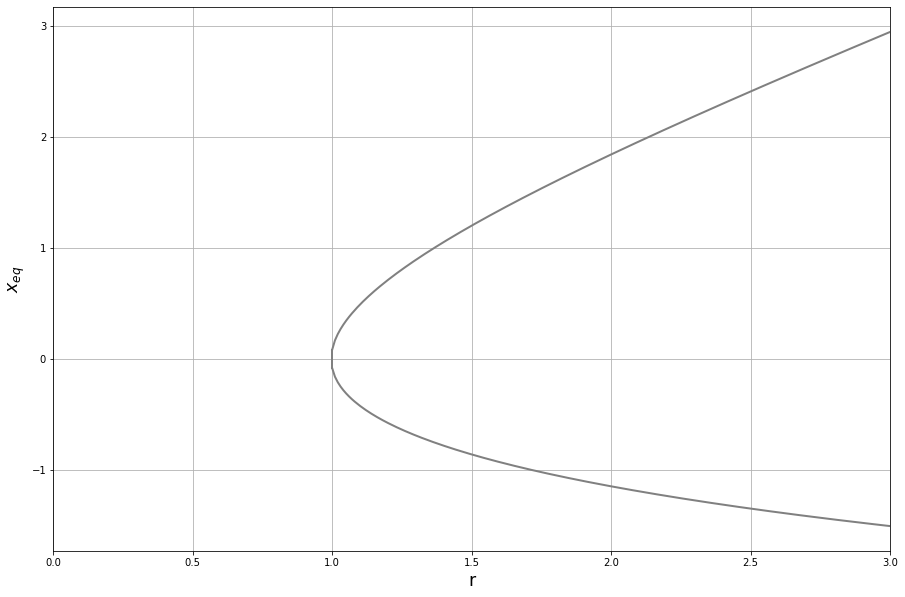

```python
import json
import os.path
rs = np.linspace(0, 3, 300)
plt.figure(figsize=(15,10))
sols = []
# define initial domain of search!
x_lower = -3
x_upper = 3.5
root_domain = [x_lower, x_upper]

if not os.path.isfile('solution4.js'):  # if solution file not exists
  print('>>No solution file found, calculating solutions.')
  print('>>Takes a long time...')
  for i, r in enumerate(rs):
      print ('Handling r = %f, %d more to go.' % (r,rs.size - i -1))
      f=lambda x:r-x-math.exp(-x)
      sol = []
      # call function for calculating roots in domain
      roots(f, root_domain[0], root_domain[-1])
      sols.append(sol)

      # Ploting
      plt.plot(r * np.ones_like(sol), sol, 'o', color='gray',
            markersize=3, linewidth=1,
            markerfacecolor='white',
            markeredgecolor='gray',
            markeredgewidth=2)
  print('Finnaly done!')
  # open output file for writing
  with open('solution4.js', 'w') as filehandle:
      json.dump(sols, filehandle)
else:
  print('Skip calculating! Loading solution file.')
  # open output file for reading
  with open('solution4.js', 'r') as filehandle:
      sols = json.load(filehandle)
  arr = np.array(sols[100:300])
  arr = np.transpose(arr)
  sols = arr.tolist()
  rs = np.linspace(1, 3, 200)

  plt.plot(rs , sols[0], '-', color='gray',
            linewidth=2,
            markeredgecolor='gray',
            markeredgewidth=2)
  plt.plot(rs, sols[1], '-', color='gray',
            linewidth=2,
            markeredgecolor='gray',
            markeredgewidth=2)
  plt.plot([1,1], [sols[0][0], sols[1][0]], '-',
           color='gray',
            linewidth=2,
            markeredgecolor='gray',
            markeredgewidth=2)
  plt.xlabel('r',size='xx-large')
  plt.ylabel('$x_{eq}$',size='xx-large')
  plt.xlim([0, 3])
  plt.grid(True)
```

**Please note that the bottom half of the graph should be dotted(because they are unstable equilibrium points, explained later)**

Then let's approximate the function with Taylor series:

$$ \begin{align} p(x) = r-x-e^{-x} & = r-\sum _{k=0}^{\infty } \frac{(-x)^k}{k!}-x \\ & = r-1-\frac{x^2}{2}+\frac{x^3}{6}-\frac{x^4}{24}+\frac{x^5}{120}-\frac{x^6}{720}+\frac{x^7}{5040}-\frac{x^8}{40320}+O\left(x^{9}\right) \end{align} $$

Let's check how many order of approximation will be sufficient to obtain close roots.

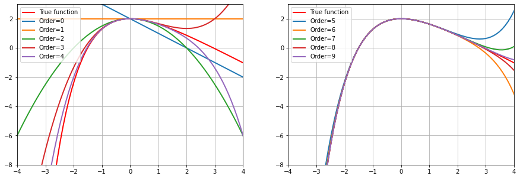

```python
r = 3
num_order = 10
# create numpy array of values of true values
x = np.linspace(-5,5,100)
true_y = r - x - np.exp(-x)

# create numpy array of values of f(x)
ys = np.empty((0, x.size))
for i in range(num_order):
  y = np.zeros_like(x)
  y += r -x
  for k in range(i+1):
    y +=- np.power(-x,k)/math.factorial(k)
  y = np.expand_dims(y, 0)
  ys = np.append(ys, y, axis=0)

# Plotting
fig, (ax1, ax2) = plt.subplots(1, 2, figsize=(15,5))

ax1.plot(x, true_y, '-', color='red', linewidth=2)
ax1.set(xlim=[-4,4], ylim=[-8,3])
ax2.set(xlim=[-4,4], ylim=[-8,3])
ax2.plot(x, true_y, '-', color='red', linewidth=2)

legend_lst = ['True function','Order=0','Order=1','Order=2','Order=3','Order=4']
for i in range(round(num_order/2)):
  ax1.plot(x, ys[i], '-',
            linewidth=2,
            markeredgewidth=2)
#   legend_lst.append('Order='+str(i))

ax1.grid(True)
ax1.legend(legend_lst, loc='upper left')

legend_lst = ['True function','Order=5','Order=6','Order=7','Order=8','Order=9']
for i in range(round(num_order/2),num_order):
  ax2.plot(x, ys[i], '-',
            linewidth=2,
            markeredgewidth=2)
#   legend_lst.append('Order='+str(i))

ax2.grid(True)
ax2.legend(legend_lst, loc='upper left')
```

From the graph, we can conclude that Taylor series with order up till 9 has a good approximation of $p(x)$.

```python
import warnings
warnings.filterwarnings('ignore', 'The iteration is not making good progress')
from scipy.optimize import fsolve

def func(x):
    return r -1-np.power(x,2)/2+ np.power(x, 3)/6-\
    np.power(x, 4)/24+np.power(x, 5)/120\
    - np.power(-x,6)/math.factorial(6)\
    - np.power(-x,7)/math.factorial(7)\
    - np.power(-x,8)/math.factorial(8)\
    - np.power(-x,9)/math.factorial(9)
```

```
Skip calculating! Loading solution file.
```

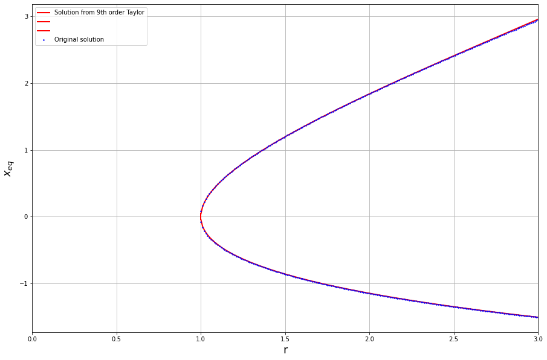

```python
import json
import os.path
rs = np.linspace(1.001, 3, 200)
plt.figure(figsize=(15,10))
sols = []
sols_up =[]
sols_down =[]
# define initial domain of search!
rootsearch = [-3, 3]

if not os.path.isfile('solution4_9.js'):  # if solution file not exists
  print('>>No solution file found, calculating solutions.')
  print('>>Takes a long time...')
  for i, r in enumerate(rs):
      print ('Handling r = %f, %d more to go.' % (r,rs.size - i -1))
      sol_up = 0
      sol_down = 0
      # call function for calculating roots
      sol_up = fsolve(func, rootsearch[0]).item()
      sol_down = fsolve(func, rootsearch[1]).item()
      sols_up.append(sol_up)
      sols_down.append(sol_down)

  sols = [sols_up, sols_down]
  # open output file for writing
  with open('solution4_9.js', 'w') as filehandle:
      json.dump(sols, filehandle)
  plt.plot(rs , sols_up, '-', color='red',
            linewidth=2,
            markeredgecolor='red',
            markeredgewidth=2)
  plt.plot(rs, sols_down, '-', color='red',
            linewidth=2,
            markeredgecolor='red',
            markeredgewidth=2)
else:
  print('Skip calculating! Loading solution file.')
  # open output file for reading
  with open('solution4_9.js', 'r') as filehandle:
      sols = json.load(filehandle)
  [sols_up, sols_down] = sols
  plt.plot((1, 1) , (sols_up[0],sols_down[0]) , '-', color='red',
            linewidth=2,
            markeredgecolor='red',
            markeredgewidth=2)
  plt.plot(rs , sols_up, '-', color='red',
            linewidth=2,
            markeredgecolor='red',
            markeredgewidth=2)
  plt.plot(rs, sols_down, '-', color='red',
            linewidth=2,
            markeredgecolor='red',
            markeredgewidth=2)
  plt.xlabel('r',size='xx-large')
  plt.ylabel('$x_{eq}$',size='xx-large')
  plt.xlim([0, 3])
  plt.grid(True)
#
if os.path.isfile('solution4.js'):  # if solution file not exists
  with open('solution4.js', 'r') as filehandle:
      sols = json.load(filehandle)
  arr = np.array(sols[100:300])
  arr = np.transpose(arr)
  sols = arr.tolist()
  rs = np.linspace(1, 3, 200)

  plt.plot(rs , sols[0], '.', color='blue', markersize=3)
  plt.plot(rs, sols[1], '.', color='blue', markersize=3)

plt.legend(['Solution from 9th order Taylor','','','Original solution'])
```

The bifurcation graph from original function and polynomial are almost colinear, we can conclude that the solutions of 9th order Taylor series is a very good approximation $p(x) = r-x-e^{-x}$ in range $x\in[-2, 3]$.

## Question 4.b (10pts) Classity the equilibrium points according to stability and explain your choice.

**Answers:**

If we choose $r = 2$ and write a small piece of code to visualize $f(x) = r-x-e^{-x}$, we can find out why two roots shows up:

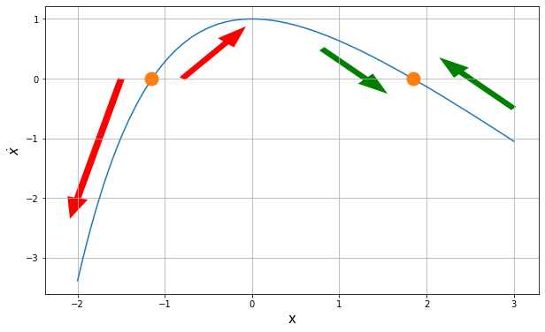

```python
x = np.linspace(-2,3,100)
y = 2 - x- np.exp(-x)
plt.figure(figsize=[10,6])
plt.plot(x,y)
plt.plot([ -1.15, 1.85],[0,0], 'o', markersize=15)
plt.grid(True)
plt.xlabel('x', fontsize=15); plt.ylabel('$\dot x$', fontsize=15)
plt.arrow(x=-1.5, y=0, dx=-0.5, dy=-2, width=.08, facecolor='red', edgecolor='none')
plt.arrow(x=-0.8, y=0, dx=0.5, dy=0.6, width=.08, facecolor='red', edgecolor='none')
plt.arrow(x=3, y=-0.5, dx=-0.6, dy=0.6, width=.08, facecolor='green', edgecolor='none')
plt.arrow(x=0.8, y=0.5, dx=0.5, dy=-0.5, width=.08, facecolor='green', edgecolor='none')
```

There are two roots when $r=2$ one is negative and the other is positive. The negative one is unstable because $f'(\chi_{eq}(-))>0$, if $x>\chi_{eq}(-)$, x will further increase since $\dot x>0$.

The positive one is stable because $f'(\chi_{eq}(+))<0$, if $x>\chi_{eq}(+)$, x will go back to $\chi_{eq}(+)$ since $\dot x<0$.

The above statements always hold when $r>1$. because $f'(0) = 0$, the function $f(x) = r-x-e^{-x}$ always 'turns' at $x=0$ . So we can further conclude that when $r>1$ ,the negative $\chi_{eq}$ is **UNSTABLE** and the positive $\chi_{eq}$ is **STABLE**